# Assignment 4

Max Diamond and Mauricio Collado

11/15/2019

## 1. Introduction

There is evidence that Marine Protected Areas (MPA) have more resilient kelp ecosystems compared with areas without any fishery regulation (Reed, 2019).

In this context, this work will evaluate the long-term effect of the protection of the local marine ecosystems of Naples and Isla Vista (Southern California). Specifically, we will analyze the change in the abundance, distribution and carapace size in the spiny lobster population. The spiny lobster plays an crucial role in protecting the kelp forest from being decimated by predators (ie. purple sea urchin). Simultaneously, the kelp forest sustain the marine biodiversity and captures the carbon excess in the sea (Tegner, M. Levin,L., 1983).

In addition, we will control the results in the MPA by comparing them with samples taken from the following non-MPA zones: Arroyo Quemado (Aquemado), Mohawk and Carpinteria. This comparison enables the analysis of fishing pressure on the marine species population.

This document is divided in three parts. In the second section, we review the data and methods. Next, we present the main results . Lastly, we summarize findings in the conclusions.

## 2. Data and methods

We employ the dataset collected by Santa Barbara Coastal Long-term Ecological Research (LTER). This data has an 8 year time span (2012-2019). It contains two tables: 1) Lobster abundance and size data, collected annually prior to the fishing season, and 2) Fishing pressure measured by counting the total quantity of commercial traps. In this study, we focus only on the first table.

The dataset includes 2 MPA sites IVEE (Isla Vista) and NAPL(Naple) and 3 non MPA sites AQUE (Aquemado), CARP (Carpinteria), and MOHK (Mohawk).

We employ an exploratory data visualization of the lobster distribution, accompanied by general statistics (mean, median, and standard deviation) of the lobster count and carapace size.

From there, we proceed with Welch’s t-test and Cohen’s D effect size test.

## 3. Results

### 3.1 Lobster count analysis

We can infer that Naples was more severely impacted by fishing pressure in the year 2015. It took three years (2016-2018) for the population to return to the previous increasing count trend. Isla Vista, on the other hand, took one year until the counts rose again.

Between 2012-2014, all of the non-MPA sites (CARP, MOHK, AQUE) counts stayed below 125 observations. After 2014, different trends unfold at each of the three sites.In the case of Mohawk, the lobster counts more than doubles, reaching over 250 counted. In 2015, however, the count continues to decrease into the present day. In Carpinteria, the count rises between 2015 and 2017. In 2017, a dramatic count decrease occurs. Finally, Aquemado witnessed a count decrease from 2014 to 2016. In the period, 2016-2017 a marginal population increase happened and then followed but slightly decreased the next year.

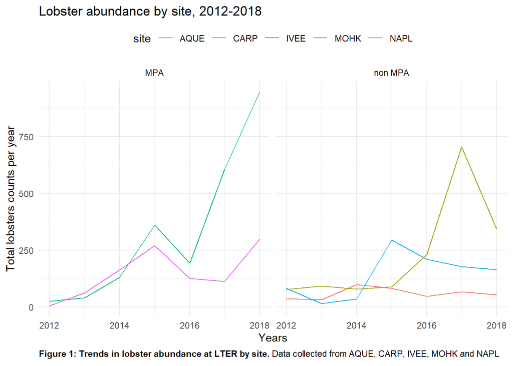

### 3.2 Lobster size distribution

In the case of the MPA (NAPL and IVEE) during 2018, the distribution accumulates towards increased carapace size compared to 2012. In 2012, the carapace size is notably smaller; the distribution is concentrated around 60 mm.

IVEE experienced an extreme change in the data distribution. In 2012, the carapace size is mostly distributed around 60mm, whereas in 2018, the shell size distribution has expanded significantly (around 80 mm). In Naples:, the 2012 size of carapace distribution is mostly even, spread out from 60mm to 90mm. In 2018, there is a greater concentration on increased shell size, extending from 70mm-100mm before the distribution narrowed out.

In the case of the non MPA sites (CARP, AQUE and MOHK), the distributions are concentrated towards the average values. In 2018, the distributions became more even. Thus, there are no additional meaningful findings, which leads us to do the statistical analysis.

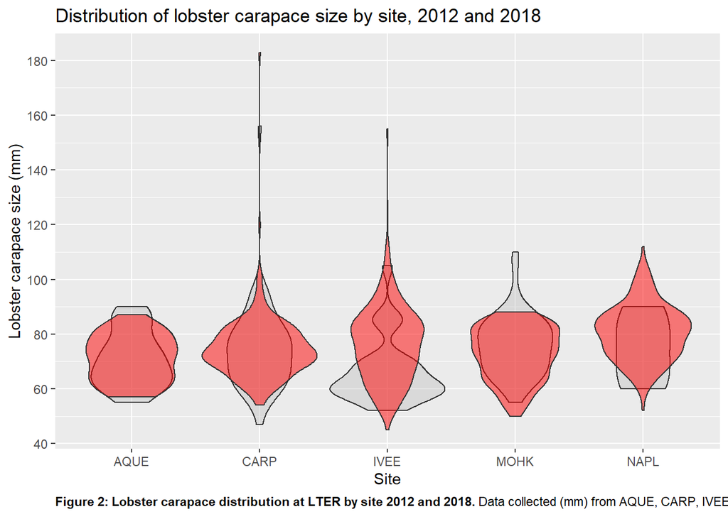

### 3.3 Exploratory analysis

In the case of non MPA sites, the mean in the lenght of carapace size dont differ between the year 2012 and 2018. However, there is an important difference in the means of carapace size from 2012 to 2018: they went from 67.7 mm to 77.8 mm (an increase of 14.92 %). We witness the same behavior with the median.

Hower, the number of observations of the MPA sites in 2012 is concerning because there are only 30 sample observation. It is understandable because this was the first year the policy was active and the data was collected. Furthermore, an additional issue is that there are barely enough MPA observations to uphold the central limit theorem in the year 2012. Specifically, a shortcoming of the available data is that there are many missing observations.

Table 1: General statistics by year and MPA category

| Items | Observations | Mean | Median | StandardDeviation |
| --- | --- | --- | --- | --- |
| MPA 2012 | 30 | 67.7 | 64.5 | 12.5 |
| Non MPA 2012 | 155 | 74.2 | 74.0 | 12.9 |
| MPA 2018 | 743 | 77.8 | 78.0 | 13.1 |
| Non MPA 2018 | 389 | 73.8 | 73.0 | 10.8 |

Own elaboration

### 3.4 Hypothesis tests

In this section, we are going to test the followin null hypothesis:

- The carapace size means between MPA and non MPA sites are the same in 2012.
- The carapace size means between MPA and non MPA sites are the same in 2018.
- The carapace size means between 2012 and 2018 are the same for MPA sites.
- The carapace size means between 2012 and 2018 are the same for non MPA sites.

Table 2: T-test and Cohen size effect test

| Items | Mean.MPA | Mean.non.MPA | P.value | Cohen.test |
| --- | --- | --- | --- | --- |
| MPA vs non MPA 2012 | 67.7 | 74.2 | 0.01258 | 0.51 |
| MPA vs non MPA 2018 | 77.8 | 73.8 | 0.00000 | 0.32 |

Own elaboration

**The carapace size means between MPA and non MPA sites are the same in 2012**

For 2012 observations, the MPA site lobster carapace size (67.7 $\pm$ 12.5, n = 30) differed significantly from the carapace size in non MPA site (74.2 $\pm$ 12.9, n = 155) by non paired t-test (t(41.87) = -2.61, p-value = 0.01258, *p* < 0.05). The difference in mean lobster shell size between the two groups is 6.5 mm, and the effect size is moderate (Cohen’s d= 0.51). The moderate effect size supports the evidence of different means in shell size between MPA and non MPA sites in 2012.

Table 3: T-test and Cohen size effect test

| Items | Mean.2018 | Mean.2012 | P.value | Cohen.test |
| --- | --- | --- | --- | --- |
| MPA 2018 vs 2012 | 77.8 | 67.7 | 0.00014 | 0.77 |
| Non MPA 2018 vs 2012 | 73.8 | 74.2 | 0.73230 | 0.04 |

Own elaboration

**The carapace size means between 2012 and 2018 are the same for MPA sites**

For MPA observations, the 2012 lobster carapace size (67.7 $\pm$ 12.5, n = 30) differed significantly from the carapace size in 2018 (77.8 $\pm$ 13.1, n = 743) by non paired t-test (t(31.63) = 4.32, p-value = 1.410^{-4}, *p* < 0.05). The difference in mean lobster shell size between the two groups is 10.1 mm, and the effect size is high (Cohen’s d= 0.77). The high effect size supports the evidence of different means in shell size between the years 2012 and 2018.

**The carapace size means between 2012 and 2018 are the same for non MPA sites**

For non MPA observations, the 2012 lobster carapace size (74.2 $\pm$ 12.9, n = 155) is the same as the carapace size in 2018 (73.8 $\pm$ 10.8, n = 389) by non paired t-test (t(244.82) = -0.34, p-value = 0.7323, *p* > 0.05). The difference in mean lobster shell size between the two groups is 0.4 mm, and the effect size is low (Cohen’s d= 0.04). But, the effect size indicates that rejecting the null hyphotesis of similarity between the means isnt robust.

## References

- Kroetz, K., Collado, M., Sanchirico, J., Galarza, E., Corderi, D. Swiedler, and Swiedler (2018). Examination of the Peruvian Anchovy Individual Vessel Quota (IVQ) System. Marine Policy Journal 101, 15-24.
- Reed (2019). Santa Barbara Coastal Long-term Ecological Research Network Data Portal.Link: https://portal.lternet.edu/nis/mapbrowse?packageid=knb-lter-sbc.77.3
- Tegner, M. Levin,L. (1983). Spiny lobsters and sea urchins: Analysis of a predator-prey interaction, Journal of Experimental Marine Biology and Ecology, Volume 73, Issue 2, Pages 125-150 Link: https://www.sciencedirect.com/science/article/pii/0022098183900795

## Appendix

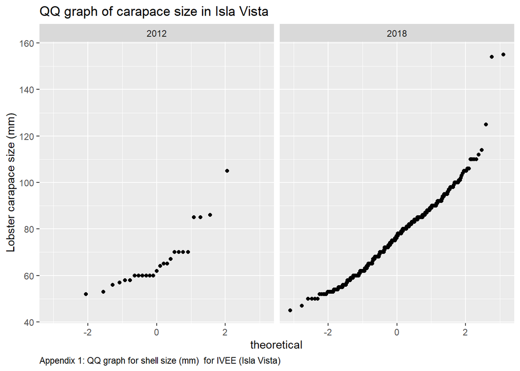

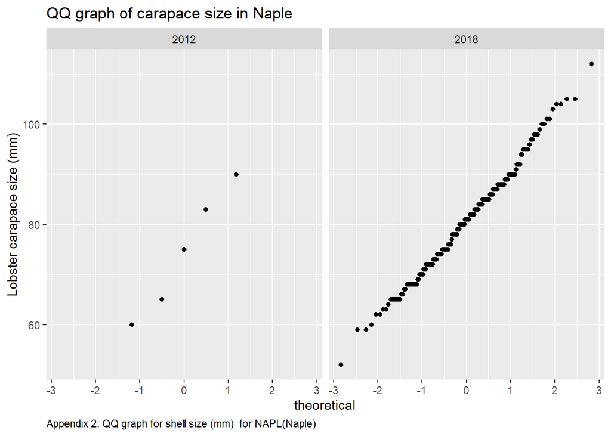

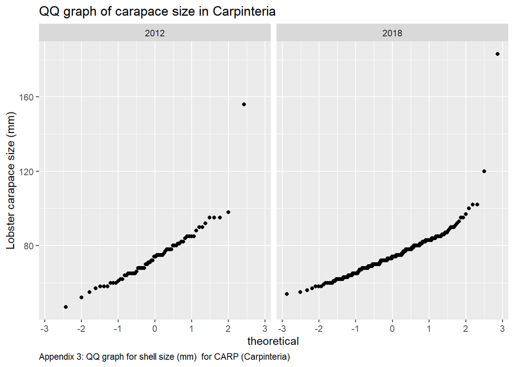

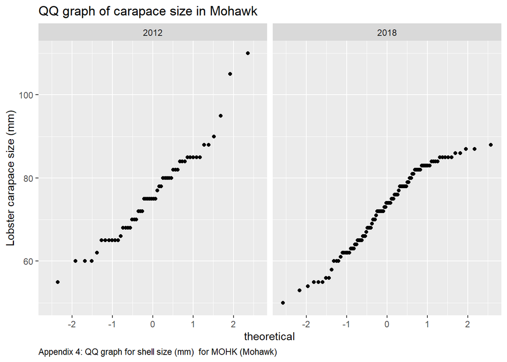

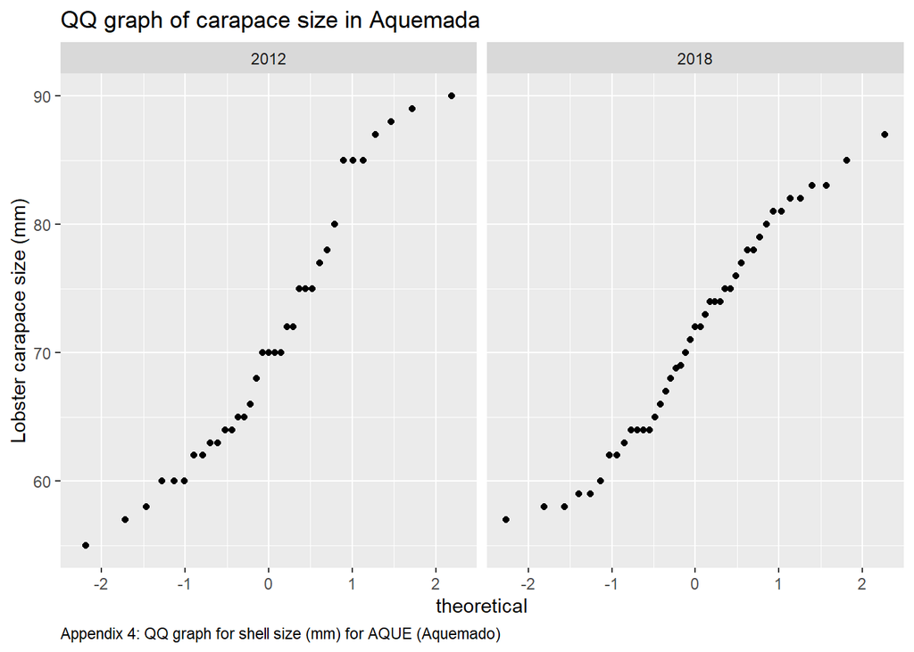